# Complementing theory on adolescent emotion regulation using machine learning

<sup>1</sup>: Utrecht University, dept. Methodology & Statistics | Open Science Community Utrecht  
Funded by NWO Veni grant VI.Veni.191G.090

## Emotion regulation in adolescence

Developmentally sensitive period (Zimmermann and Iwanski 2014)

20% develop psychopathology (Lee et al. 2014)

Potentially lifelong implications for mental health and well-being

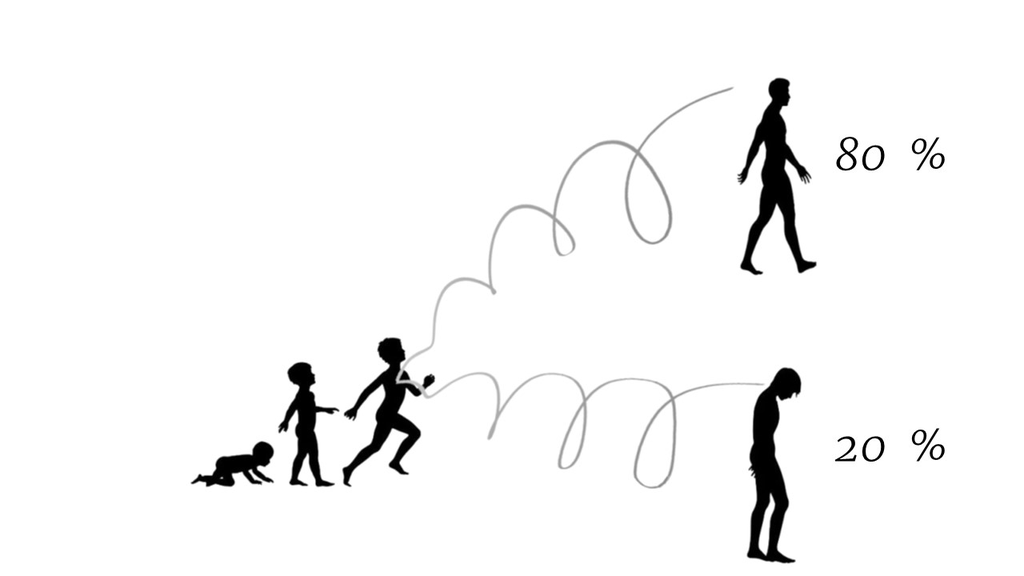

## Knowledge gap

Substantial empirical research, but:

- Different (sub)disciplines have approached the topic in disparate ways (Riediger and Klipker 2014)
- No consistent terminology (Bariola, Gullone, and Hughes 2011)
- No conceptual frameworks (Stifter and Augustine 2019)
- No overarching theoretical framework (Buss, Cole, and Zhou 2019)

Knowledge must be consolidated into overarching theory

## Relevant theory

- Bioecological model (Bronfenbrenner and Morris 2007)
- Transactional model (Sameroff 2010)
- Hall’s notion of “storm and stress”
- Theory of normative emotional development (Sroufe 1995)
- Tripartite model (Morris et al. 2007)
- Internalization model (Holodynski and Friedlmeier 2006)
- Polyvagal theory (Porges 1995).
- Model of social-affective engagement and goal flexibility (Crone and Dahl 2012)
- Process model of emotion regulation (Gross 2013)
- Social Information Processing Theory (Lemerise and Arsenio 2000)

## Limitations of relevant theory

- Few explicitly address adolescence
- Few comprehensively address predictors of emotion regulation
- None directly guide contemporary research
- Theories vary widely in scope: Some are broad and non-specific; others describe a specific phenomenon in detail, but lack a broader perspective.
  - Broad theories can frame any research, specific theories generate hypotheses.
  - It would be beneficial to bridge these levels of analysis.

## Towards integrative theory

First step: identifying relevant phenomena (Borsboom et al. 2020)

We conducted a text mining systematic review (TMSR) (van Lissa 2021)

- Narrative reviews: small samples, confirmation bias, emphasize positive results (Littell 2008)
- TMSR: Unlimited sample size, transparent, objective, reproducible

6653 papers on Addresses **emotion regulation** in population overlapping with adolescence [10-24]

<doi.org/10.1007/s40894-021-00160-7>

## Co-occurrence graph

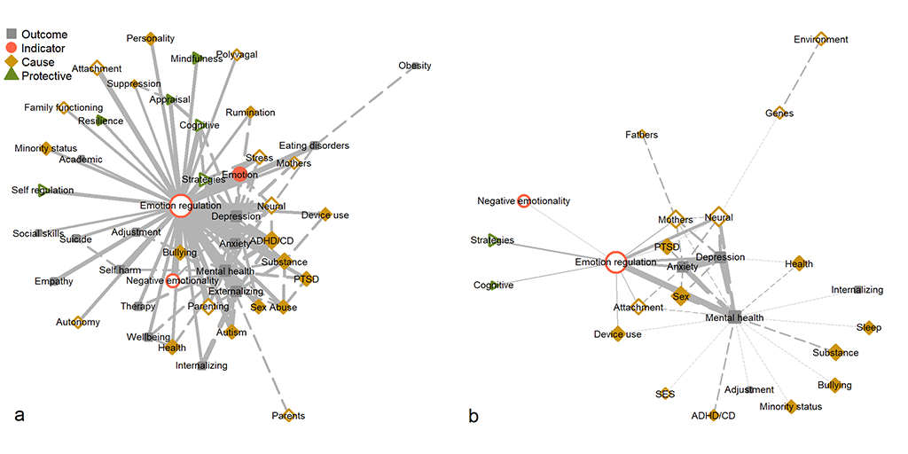

Author keywords (a) and abstracts (b)

## Next step

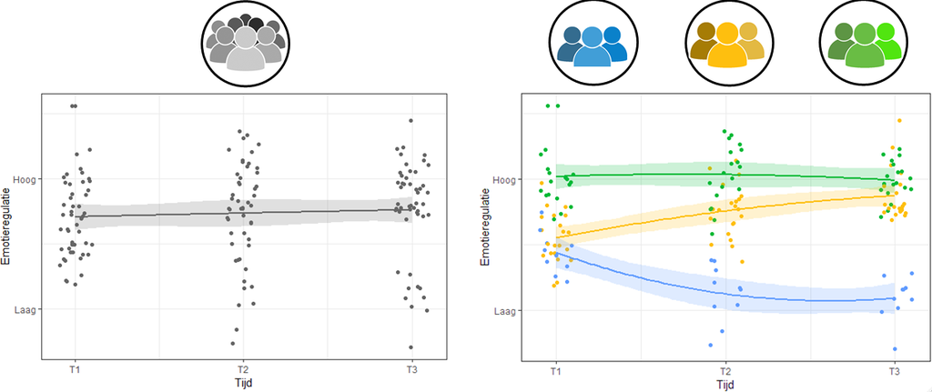

- Predictors of latent growth model?
  - Only linear differences, few predictors (power)
- Multigroup latent growth model?
  - Non-linear differences, but only one moderator
- Latent class growth model with auxilliary variables?
  - Groups with regard to trajectory, not predictors

## Solution: Machine learning

- Allows non-linear differences between trajectories
- Performs variable selection
  - Cast wide net among potentially relevant predictors
- Checks & balances ensure generalizability
- Exploratory: No hypothesis

## Method illustrated

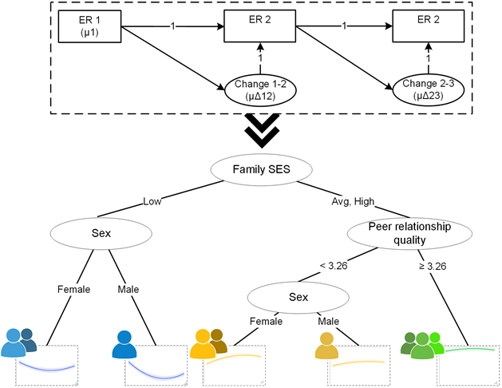

## Method

SEM-forest (Brandmaier et al. 2016)

1. Bootstrap sample
2. On each sample, estimate a SEM-model
3. Consider \(k\) candidate predictors
4. Identify predictor and value that maximizes \(LR\) of post-split multi-group model
5. Average predictions across bootstrap samples

We used 1000 bootstrap samples, \(k = 9\)

## Present study

RQ1: What are the most important predictors of adolescents’ trajectories of emotion regulation development?

RQ2: What is the nature of the association of the predictors with the trajectories?

**Participants**

- RADAR data (https://www.uu.nl/en/research/radar)
- 497 Dutch adolescents (283 boys; age at T1: M =13.03, SD = 0.46)
- Collected between 2006-2011
- Most families were medium- to high-SES (10% low-SES)

## Candidate predictors

Predictors: 87

Categories:

- Demographics (e.g., SES)
- Biological (age, sex, pubertal development)
- Individual differences (big5, BIS/BAS, empathy)
- Risk behavior (in/externalizing symptoms, substance use, delinquency, school performance, victimization)
- Relationship quality (parents/peers)
- Parenting (perceived and parent-reported)
- Conflict resolution styles

## Dependent variable

Difficulties in emotion regulation (Gratz and Roemer 2004)

- 24 items (omitted ‘emotional awareness’ subscale)
- E.g.: “When I’m upset, I have difficulty thinking about anything else”
- 1 (“Almost never”) to 5 (“Almost always”)
- Excellent reliability, \((.94 > \alpha > .95)\).
- Metric invariance across waves
- Quadratic growth model had good fit
  - CFI = .996, TLI = .993, RMSEA = .047, SRMR = 0.020

## Open science

Workflow for Open Reproducible Code in Science (WORCS) used to make analyses reproducible (Van Lissa et al. 2020)

All code and synthetic data available at

https://github.com/cjvanlissa/veni_forest

## Results

## Variable importance

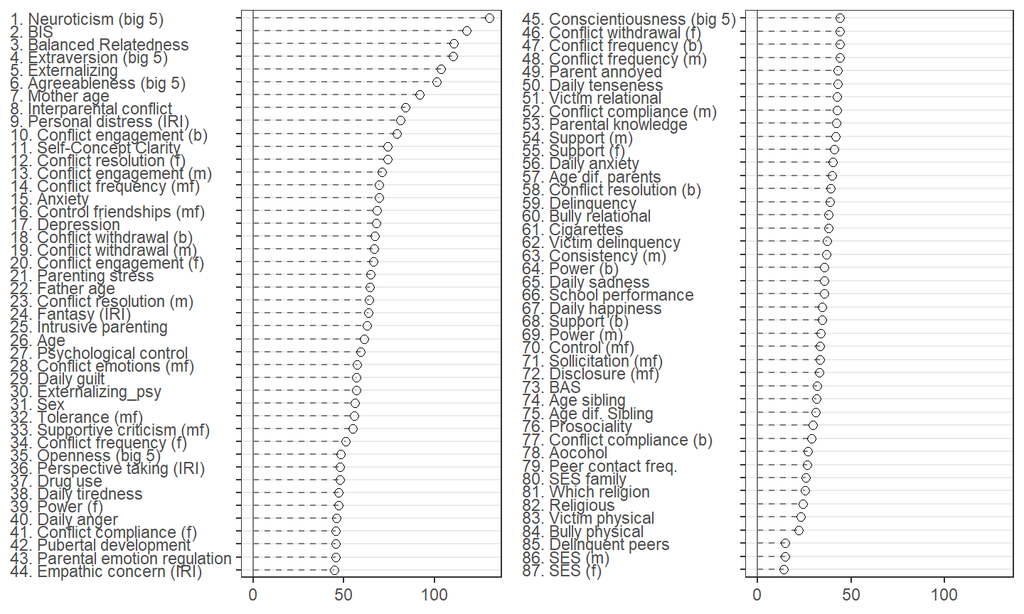

## Marginal association

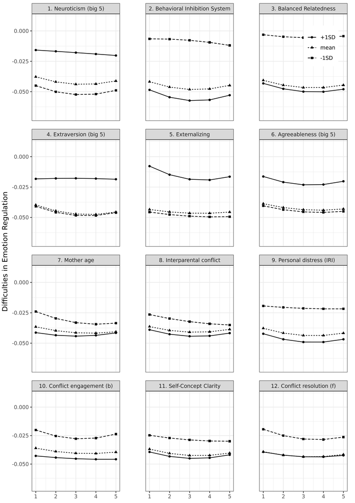

## Marginal association 2

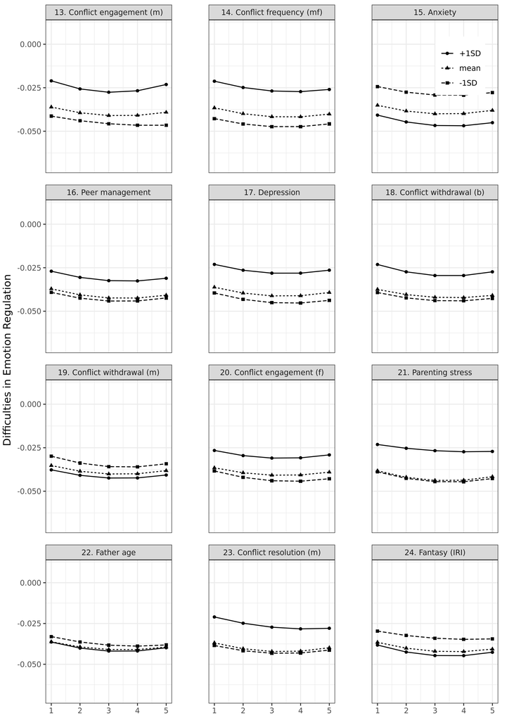

## Marginal association 3

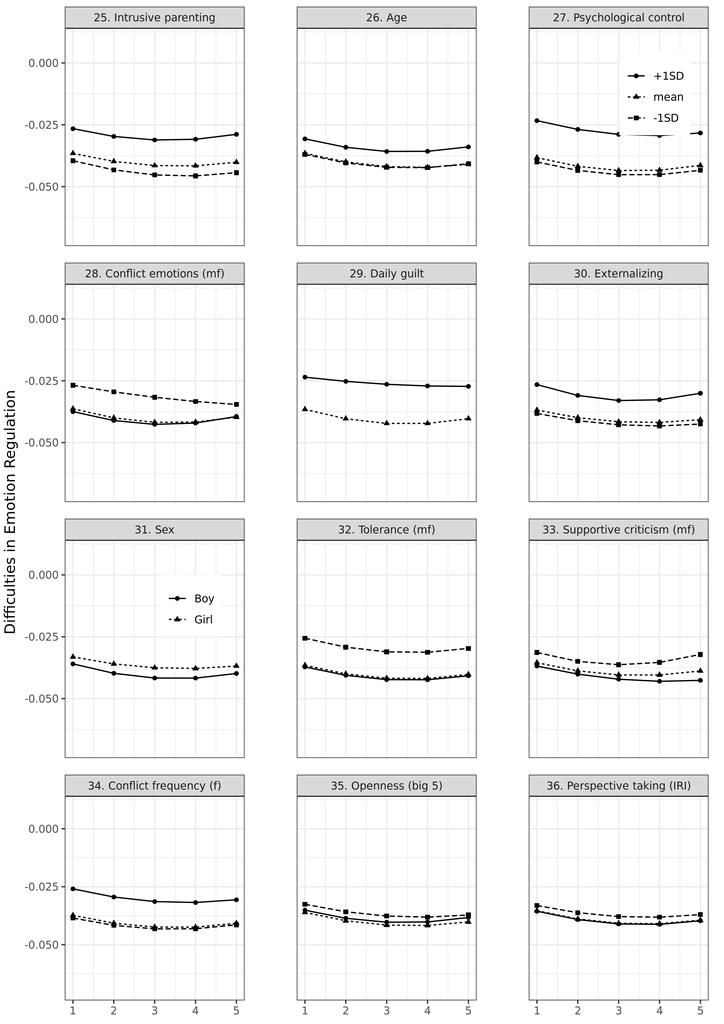

## Marginal association 4

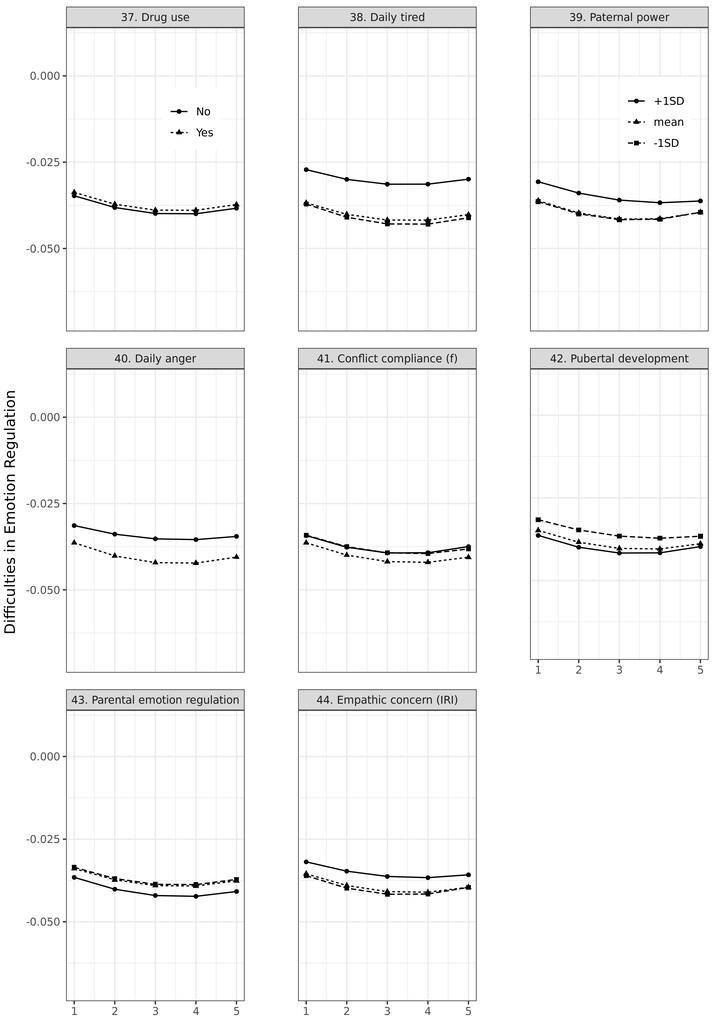

## Summary

Important:

- Best predictors: Personality and related constructs
- Best parental predictor is autonomy support (bal. rel.)
  - Negative/intrusive parenting more predictive than other positive practices
- Conflict frequency and behavior
- Empathy, particularly personal distress

Less important than expected:

- SES
- Bullying/victimization
- Delinquency
- Substance use
- Monitoring

## Reflection content

- Most important predictors are routinely assessed (big 5) or overt (conflict)
  - Prime candidates for early risk assessment
  - Conflict resolution behavior can be taught
    - Target for intervention if association is causal
- Emphasis on parenting (in literature and theory) might not be justified
  - Congruent with RI-CLPM showing few parenting effects in adolescence (Van Lissa et al. 2019)
- Order of predictors mirrors bioecological model

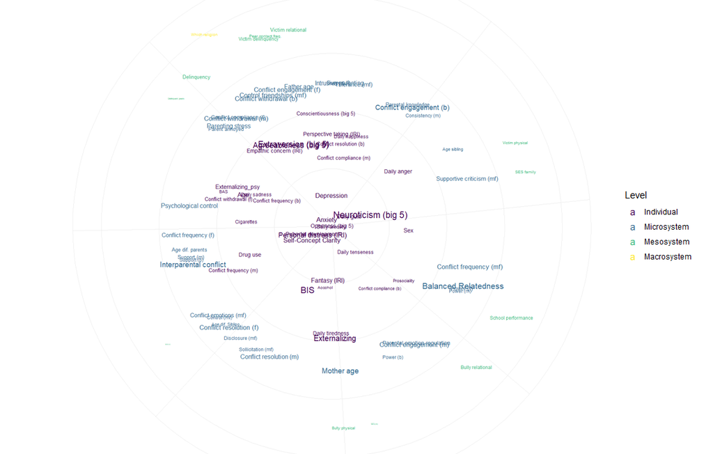

## Reflections form

- Many predictors show non-linear effects: Emotion dysregulation only for +/-1SD
- Some predictors show almost no marginal effect (e.g., father’s age, drug use)
  - This suggests they might be important in **interactions**

## Limitations

- Selective sample
  - WEIRD, Dutch, mostly mid- high-SES (restriction of range)
- Panel study, so few biological / cognitive / neurological measures
- Relatively small sample size
  - If you have access to 1000+ sample, please get in touch
- Computational constraints prevented us from tuning the model beyond default settings, and from exploring marginal effects for higher order interactions

## Conclusions

- Proximal factors more predictive of ER development than distal predictors
- Parenting may be less relevant than previously thought
- Personality and conflict behavior are candidates for early diagnosis
- Conflict skills training might be avenue for intervention

## References

Bariola, Emily, Eleonora Gullone, and Elizabeth K. Hughes. 2011. “Child and Adolescent Emotion Regulation: The Role of Parental Emotion Regulation and Expression.” *Clinical Child and Family Psychology Review* 14 (2): 198. https://doi.org/10.1007/s10567-011-0092-5.

Borsboom, Denny, Jonas Dalege, Rogier A Kievit, and Brian D Haig. 2020. “Theory Construction Methodology: A Practical Framework for Building Theories in Psychology.” PsyArxiv. February 29, 2020. https://doi.org/10.31234/osf.io/w5tp8.

Brandmaier, Andreas M., John J. Prindle, John J. McArdle, and Ulman Lindenberger. 2016. “Theory-Guided Exploration with Structural Equation Model Forests.” *Psychological Methods* 21 (4): 566–82. https://doi.org/10.1037/met0000090.

Bronfenbrenner, Urie, and Pamela A. Morris. 2007. “The Bioecological Model of Human Development.” In *Handbook of Child Psychology*. John Wiley & Sons, Inc. https://doi.org/10.1002/9780470147658.chpsy0114.

Buss, Kristin A., Pamela M. Cole, and Anna M. Zhou. 2019. “Theories of Emotional Development: Where Have We Been and Where Are We Now?” In *Handbook of Emotional Development*, edited by Vanessa LoBue, Koraly Pérez-Edgar, and Kristin A. Buss, 7–25. Cham: Springer International Publishing. https://doi.org/10.1007/978-3-030-17332-6_2.

Crone, Eveline A., and Ronald E. Dahl. 2012. “Understanding Adolescence as a Period of Social–Affective Engagement and Goal Flexibility.” *Nature Reviews Neuroscience* 13 (9): 636–50. https://doi.org/10.1038/nrn3313.

Gratz, Kim L., and Lizabeth Roemer. 2004. “Multidimensional Assessment of Emotion Regulation and Dysregulation: Development, Factor Structure, and Initial Validation of the Difficulties in Emotion Regulation Scale.” *Journal of Psychopathology and Behavioral Assessment* 26 (1): 41–54. https://doi.org/10.1023/B:JOBA.0000007455.08539.94.

Gross, James J. 2013. *Handbook of Emotion Regulation*. Book, Whole. Guilford publications.

Holodynski, Manfred, and Wolfgang Friedlmeier. 2006. *Development of Emotions and Emotion Regulation*. Springer Science & Business Media. https://books.google.com?id=OvJHncpZEQUC.

Lee, Francis S., Hakon Heimer, Jay N. Giedd, Edward S. Lein, Nenad Šestan, Daniel R. Weinberger, and B. J. Casey. 2014. “Adolescent Mental Health— Opportunity and Obligation.” *Science* 346 (6209): 547–49. https://doi.org/10.1126/science.1260497.

Lemerise, Elizabeth A., and William F. Arsenio. 2000. “An Integrated Model of Emotion Processes and Cognition in Social Information Processing.” *Child Development* 71 (1): 107–18. https://doi.org/10.1111/1467-8624.00124.

Littell, Julia H. 2008. “Evidence-Based or Biased? The Quality of Published Reviews of Evidence-Based Practices.” *Children and Youth Services Review* 30 (11): 1299–1317. https://doi.org/10.1016/j.childyouth.2008.04.001.

Morris, Amanda Sheffield, Jennifer S. Silk, Laurence Steinberg, Sonya S. Myers, and Lara Rachel Robinson. 2007. “The Role of the Family Context in the Development of Emotion Regulation.” *Social Development* 16 (2): 361–88. https://doi.org/10.1111/j.1467-9507.2007.00389.x.

Porges, Stephen W. 1995. “Orienting in a Defensive World: Mammalian Modifications of Our Evolutionary Heritage. A Polyvagal Theory.” *Psychophysiology* 32 (4): 301–18. https://doi.org/10.1111/j.1469-8986.1995.tb01213.x.

Riediger, Michaela, and Kathrin Klipker. 2014. “Emotion Regulation in Adolescence.” In *Handbook of Emotion Regulation*, 187–202. Guilford Press.

Sameroff, Arnold. 2010. “A Unified Theory of Development: A Dialectic Integration of Nature and Nurture.” *Child Development* 81 (1): 6–22. https://doi.org/10.1111/j.1467-8624.2009.01378.x.

Sroufe, L. Alan. 1995. *Emotional Development: The Organization of Emotional Life in the Early Years*. Cambridge Studies in Social and Emotional Development. Cambridge: Cambridge University Press. https://doi.org/10.1017/CBO9780511527661.

Stifter, Cynthia, and Mairin Augustine. 2019. “Emotion Regulation.” In *Handbook of Emotional Development*, edited by Vanessa LoBue, Koraly Pérez-Edgar, and Kristin A. Buss, 405–30. Cham: Springer International Publishing. https://doi.org/10.1007/978-3-030-17332-6_16.

van Lissa, Caspar J. 2021. “Mapping Phenomena Relevant to Adolescent Emotion Regulation: A Text-Mining Systematic Review.” *Adolescent Research Review*, May. https://doi.org/10.1007/s40894-021-00160-7.

Van Lissa, Caspar J., Andreas M. Brandmaier, Loek Brinkman, Anna-Lena Lamprecht, Aaron Peikert, Marijn E. Struiksma, and Barbara Vreede. 2020. “ WORCS: A Workflow for Open Reproducible Code in Science,” May. https://doi.org/10.17605/OSF.IO/ZCVBS.

Van Lissa, Caspar J., Renske Keizer, Pol A. C. Van Lier, Wim H. J. Meeus, and Susan Branje. 2019. “The Role of Fathers’ Versus Mothers’ Parenting in Emotion-Regulation Development from Mid–Late Adolescence: Disentangling Between-Family Differences from Within-Family Effects.” *Developmental Psychology* 55 (2): 377–89. https://doi.org/10.1037/dev0000612.

Zimmermann, Peter, and Alexandra Iwanski. 2014. “Emotion Regulation from Early Adolescence to Emerging Adulthood and Middle Adulthood: Age Differences, Gender Differences, and Emotion-Specific Developmental Variations.” *International Journal of Behavioral Development* 38 (2): 182–94.